# Titanic

## The dataset under analysis used is the TITANIC data

## Following are the question I posed

#### 1.What is the tentative fare for each class of passengers?

#### 2.What is the age of passengers onboard depending on the class of passengers?

#### 3.How many family members were onboard for casualties?

#### 4.What proportion of casualties were female and what proportion of casualties were male?

#### 5.What proportion of male and female casulaties belong to 1st, 2nd and 3rd class?

```python
import pandas as pd
import numpy as np
%matplotlib inline
from matplotlib import pyplot as plt
import seaborn as sns
```

#### The above mentioned libraries have been used for the purpose of analysis.

## Data Wrangling - Data Aquisition

### Reading csv file to dataframe using pandas

```python
titanic_df = pd.read_csv('titanic-data.csv')
```

```python
titanic_df.head()
```

|  | PassengerId | Survived | Pclass | Name | Sex | Age | SibSp | Parch | Ticket | Fare | Cabin | Embarked |
| --- | --- | --- | --- | --- | --- | --- | --- | --- | --- | --- | --- | --- |
| 0 | 1 | 0 | 3 | Braund, Mr. Owen Harris | male | 22.0 | 1 | 0 | A/5 21171 | 7.2500 | NaN | S |
| 1 | 2 | 1 | 1 | Cumings, Mrs. John Bradley (Florence Briggs Th... | female | 38.0 | 1 | 0 | PC 17599 | 71.2833 | C85 | C |
| 2 | 3 | 1 | 3 | Heikkinen, Miss. Laina | female | 26.0 | 0 | 0 | STON/O2. 3101282 | 7.9250 | NaN | S |
| 3 | 4 | 1 | 1 | Futrelle, Mrs. Jacques Heath (Lily May Peel) | female | 35.0 | 1 | 0 | 113803 | 53.1000 | C123 | S |
| 4 | 5 | 0 | 3 | Allen, Mr. William Henry | male | 35.0 | 0 | 0 | 373450 | 8.0500 | NaN | S |

## Data Wrangling - Data Cleaning

```python
titanic_df.info()
```

```
<class 'pandas.core.frame.DataFrame'>
RangeIndex: 891 entries, 0 to 890
Data columns (total 12 columns):
PassengerId    891 non-null int64
Survived       891 non-null int64
Pclass         891 non-null int64
Name           891 non-null object
Sex            891 non-null object
Age            714 non-null float64
SibSp          891 non-null int64
Parch          891 non-null int64
Ticket         891 non-null object
Fare           891 non-null float64
Cabin          204 non-null object
Embarked       889 non-null object
dtypes: float64(2), int64(5), object(5)
memory usage: 66.2+ KB
```

#### The above data shows us that there are many missing values for the fields like age,cabin and embarked. Also after looking into the dataset I found that many values for the Fare field are set to 0.

#### To fill in the missing values for age field, the way I find best is to group the data by their salutations which can be extracted from the name field and set the median of the grouped data to the missing values. Taking median seems the best way so that it neglects the effect of any outliers in the data. This might not be the best way of predicting the age, but the data does not provide with any additional information.

#### Filling the missing values for cabin and embarked fields does not seem necessary as for as the scope of this particular investigation is taken into consideration.

#### To fill in the missing values for fare field, the best way is to group data by passenger class and set the median of the grouped data to the missing class. Again, the median used is for the purpose of overlooking the outliers.

### The below function replace_fare checks for the entries having fare as 0 or empty and replaces it with median of fare belonging to a particular class

### The median has been used so that there are no effects of outliers on the dataset

```python
def replace_fare(grp):
    grp['FareNew'] = np.where(((grp['Fare'] ==0) | (grp['Fare'].isnull())), grp['Fare'].median(),grp['Fare'])
    return grp
```

```python
titanic_df = titanic_df.groupby("Pclass").apply(replace_fare)
```

#### Using the apply function we are invoking the replace fare function for each record in the dataset.

```python
print(titanic_df[((titanic_df['Fare'] ==0) | (titanic_df['Fare'].isnull()))][['FareNew','Fare','Pclass']])
```

```
     FareNew  Fare  Pclass
179   8.0500   0.0       3
263  60.2875   0.0       1
271   8.0500   0.0       3
277  14.2500   0.0       2
302   8.0500   0.0       3
413  14.2500   0.0       2
466  14.2500   0.0       2
481  14.2500   0.0       2
597   8.0500   0.0       3
633  60.2875   0.0       1
674  14.2500   0.0       2
732  14.2500   0.0       2
806  60.2875   0.0       1
815  60.2875   0.0       1
822  60.2875   0.0       1
```

### The dataset contains some entries in age which are empty. To fill these entries with appropriate data we use the salutation which can be extracted from name column and depending on the salutation the age can be predicted.

### Extracting the salutation from the name column for filtering

```python
def name_extract(word):
    return word.split(',')[1].split('.')[0].strip()
df = pd.DataFrame({'Salutation':titanic_df['Name'].apply(name_extract)})
titanic_df = pd.merge(titanic_df,df,left_index = True, right_index = True)
```

#### The above function name_extract takes record's name field as input and splits it by comma to get the 2nd part of he name field which appears after comma and again splits it using dot to get the 1st part before the dot. Using strip we remove all the spaces which could be present before or after the salutation.

#### Using pd.merge we add the salutations as an additional field to the original dataset

### The below function replace_age checks for the entries of age which are empty and replaces it with median of age belonging to a particular salutation

```python
def replace_age(grp):
    grp['AgeNew'] = np.where(grp['Age'].isnull(), grp['Age'].median(),grp['Age'])
    return grp
```

```python
titanic_df = titanic_df.groupby("Salutation").apply(replace_age)
```

#### Using the apply function we are invoking the replace_age function for each record in the dataset.

```python
print(titanic_df.head())
```

```
   PassengerId  Survived  Pclass  \
0            1         0       3
1            2         1       1
2            3         1       3
3            4         1       1
4            5         0       3

                                                Name     Sex   Age  SibSp  \
0                            Braund, Mr. Owen Harris    male  22.0      1
1  Cumings, Mrs. John Bradley (Florence Briggs Th...  female  38.0      1
2                             Heikkinen, Miss. Laina  female  26.0      0
3       Futrelle, Mrs. Jacques Heath (Lily May Peel)  female  35.0      1
4                           Allen, Mr. William Henry    male  35.0      0

   Parch            Ticket     Fare Cabin Embarked  FareNew Salutation  AgeNew
0      0         A/5 21171   7.2500   NaN        S   7.2500         Mr    22.0
1      0          PC 17599  71.2833   C85        C  71.2833        Mrs    38.0
2      0  STON/O2. 3101282   7.9250   NaN        S   7.9250       Miss    26.0
3      0            113803  53.1000  C123        S  53.1000        Mrs    35.0
4      0            373450   8.0500   NaN        S   8.0500         Mr    35.0
```

### The below function 'find_no_of_family_members' takes in the whole titanic dataframe as parameter input and returns a new dataframe with one column 'familyMembers' as sum of sibsp and parch. It uses 1D vector addition for this operation

```python
def find_no_of_family_members(data):
    data['familyMembers'] = data['SibSp'] + data['Parch']
    return data
```

### The below statement adds familyMembers column to titanic dataframe

```python
titanic_df = titanic_df.merge(find_no_of_family_members(titanic_df))
```

## Data Exploration Phase

### Data and plot presenting the average of Fare ḍepending on the class of passengers

```python
print(titanic_df.groupby(["Pclass"],as_index = False).mean()["FareNew"])
print(titanic_df.groupby(["Pclass"],as_index = False).mean()["Pclass"])
```

```
0    85.550231
1    21.126857
2    13.741131
Name: FareNew, dtype: float64
0    1
1    2
2    3
Name: Pclass, dtype: int64
```

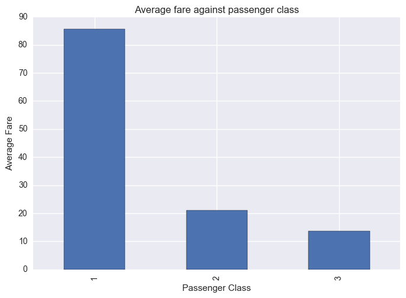

```python
titanic_df.groupby('Pclass')['FareNew'].mean().plot(kind = 'bar')
plt.xlabel('Passenger Class')
plt.ylabel('Average Fare')
plt.title('Average fare against passenger class')
```

#### From the above plot we can see that the average fare for class 1 is way higher than that for class 2 and class 3.

#### So looking at the plot, we can make an assumption that may be class 1 passengers might have been given extra facilities and beter security arrangements which might reflect in the survival rate for class 1 passengers

### Data representing the average of Age depending on the class of passengers

```python
print(titanic_df.groupby(["Pclass"],as_index = False).mean()["AgeNew"])
print(titanic_df.groupby(["Pclass"],as_index = False).mean()["Pclass"])
```

```
0    37.309815
1    29.787120
2    25.757475
Name: AgeNew, dtype: float64
0    1
1    2
2    3
Name: Pclass, dtype: int64
```

### The number of passengers grouped by survival and then by familyMembers onboard titanic

```python
survival_familyMembers_filter = titanic_df.groupby(["Survived","familyMembers"],as_index = False)["PassengerId"].count()
```

### The number of passengers who did not survive grouped by number of familyMembers onboard

```python
casualties_familyMembers_filter = survival_familyMembers_filter[survival_familyMembers_filter["Survived"]==0]
```

```python
casualties_familyMembers_filter
```

|  | Survived | familyMembers | PassengerId |
| --- | --- | --- | --- |
| 0 | 0 | 0 | 374 |
| 1 | 0 | 1 | 72 |
| 2 | 0 | 2 | 43 |
| 3 | 0 | 3 | 8 |
| 4 | 0 | 4 | 12 |
| 5 | 0 | 5 | 19 |
| 6 | 0 | 6 | 8 |
| 7 | 0 | 7 | 6 |
| 8 | 0 | 10 | 7 |

### The number of passengers who survived grouped by number of familyMembers onboard

```python
survived_familyMembers_filter = survival_familyMembers_filter[survival_familyMembers_filter["Survived"]==1]
```

```python
survived_familyMembers_filter
```

|  | Survived | familyMembers | PassengerId |
| --- | --- | --- | --- |
| 9 | 1 | 0 | 163 |
| 10 | 1 | 1 | 89 |
| 11 | 1 | 2 | 59 |
| 12 | 1 | 3 | 21 |
| 13 | 1 | 4 | 3 |
| 14 | 1 | 5 | 3 |
| 15 | 1 | 6 | 4 |

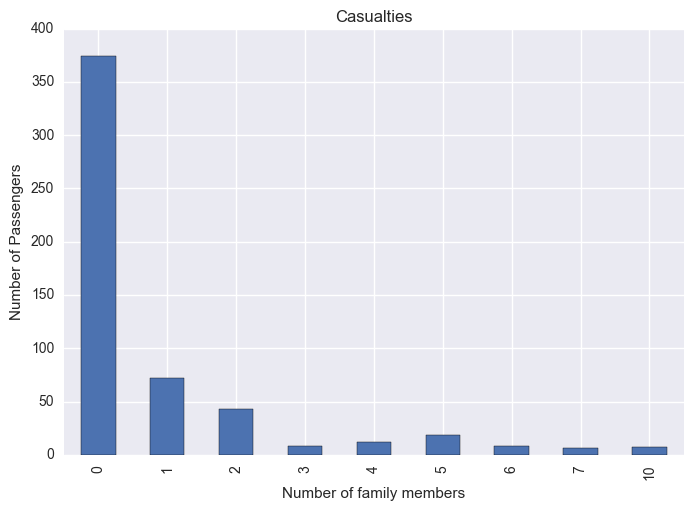

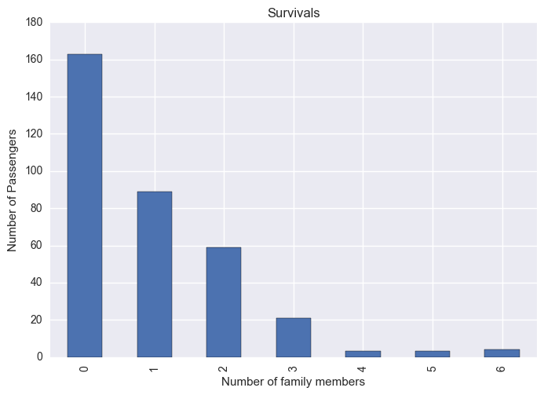

```python
casualties_familyMembers_filter.plot("familyMembers","PassengerId",kind='bar',subplots = True,legend = False)
plt.xlabel('Number of family members')
plt.ylabel('Number of Passengers')
plt.title('Casualties')

survived_familyMembers_filter.plot("familyMembers","PassengerId",kind='bar',subplots = True,legend = False)
plt.xlabel('Number of family members')
plt.ylabel('Number of Passengers')
plt.title('Survivals')
```

#### The above plots represents the number of passengers with their survival status, depending on the number of family members onboard

[output not shown]

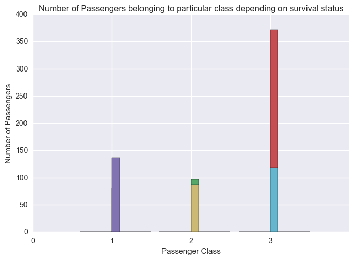

```python
titanic_df.groupby(['Survived','Pclass'])['Pclass'].hist()
plt.xlabel('Passenger Class')
plt.ylabel('Number of Passengers')
plt.title('Number of Passengers belonging to particular class depending on survival status')
plt.xticks(range(4))
```

#### The light blue, yellow and purple represent the number of survivors whereas the green and red represent the number of casualties. For class 1 the survivors and casualties seem to overlap so only the bar representing survivors is visible and hides the bar representing the casualties for class 1.

### Cells 24 to 31 focuses on finding the survivals and casualties depending upon the gender of the passengers.

#### It helps in deducing what proportion of male and female casualties occured during the incident.

#### This could also help deduce if such an incident has to happen again, which type of gender is more likely to survive.

```python
survival_gender_filter = titanic_df.groupby(["Survived","Sex"],as_index = False)["PassengerId"].count()
```

```python
survival_gender_filter
```

|  | Survived | Sex | PassengerId |
| --- | --- | --- | --- |
| 0 | 0 | female | 81 |
| 1 | 0 | male | 468 |
| 2 | 1 | female | 233 |
| 3 | 1 | male | 109 |

```python
casualties_gender_filter = survival_gender_filter[survival_gender_filter["Survived"]==0]
```

```python
casualties_gender_filter
```

|  | Survived | Sex | PassengerId |
| --- | --- | --- | --- |
| 0 | 0 | female | 81 |
| 1 | 0 | male | 468 |

```python
gender_filter = titanic_df.groupby(["Sex"],as_index = False)["PassengerId"].count()
```

```python
gender_filter
```

|  | Sex | PassengerId |
| --- | --- | --- |
| 0 | female | 314 |
| 1 | male | 577 |

```python
casualties_proportion = casualties_gender_filter["PassengerId"]/gender_filter["PassengerId"]
```

```python
casualties_proportion
```

```
0    0.257962
1    0.811092
Name: PassengerId, dtype: float64
```

### The above data shows that there were about 26% female casualties whereas about 81% male casulties during the titanic incident.

#### The proportion of male and female casualties shows us that if an incident like titanic was to happen again, then there could be a chance of more number of male casulties than female casulties.

```python
survival_gendr_pclass_filter = titanic_df.groupby(["Survived","Sex","Pclass"],as_index = False)["PassengerId"].count()
```

```python
survival_gendr_pclass_filter
```

|  | Survived | Sex | Pclass | PassengerId |
| --- | --- | --- | --- | --- |
| 0 | 0 | female | 1 | 3 |
| 1 | 0 | female | 2 | 6 |
| 2 | 0 | female | 3 | 72 |
| 3 | 0 | male | 1 | 77 |
| 4 | 0 | male | 2 | 91 |
| 5 | 0 | male | 3 | 300 |
| 6 | 1 | female | 1 | 91 |
| 7 | 1 | female | 2 | 70 |
| 8 | 1 | female | 3 | 72 |
| 9 | 1 | male | 1 | 45 |
| 10 | 1 | male | 2 | 17 |
| 11 | 1 | male | 3 | 47 |

### Among the female casualties 3.7% belonged to class 1, 7.4% belonged to class 2 and 88.88% belonged to class 3

### Among the male casualties 16.45% belonged to class 1, 19.44% belonged to class 2 and 64.1% belonged to class 3

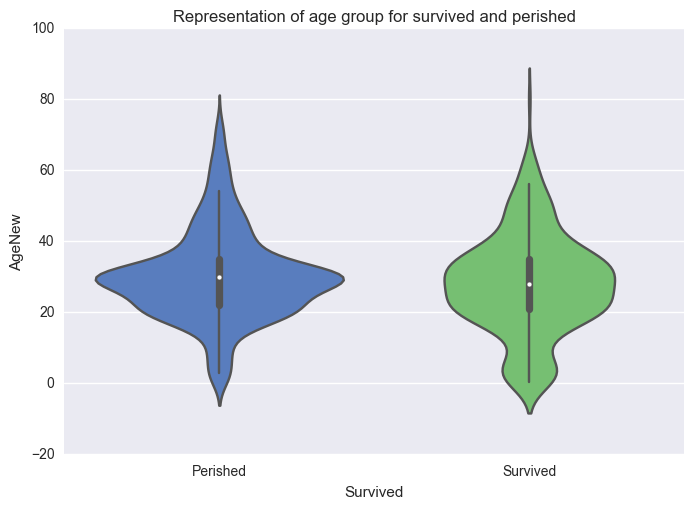

```python
plot = sns.violinplot(x="Survived", y="AgeNew",data=titanic_df, palette="muted")
sns.plt.title("Representation of age group for survived and perished")
plot.set(xticklabels=['Perished','Survived'])
```

#### The above plot shows us that a majority of people who survived or did not survive had their age ranging between 20 and 40 years.

# Report

## Investigation for the questions posed

#### To find the tentative fare for each class, finding average seemed to be the best option.

#### Even for finding the age for each class, the average has been calculated.

#### To find the number of family members, for each passenger, it has been calculated by 1D vector addition of two columns representing spouse-siblings and parent-children.

#### Then the data is grouped depending on the number of family members.

#### For the proportion of male and female casualties, the dataset was first grouped by column 'Survived' and furthur grouped by column 'Sex'.

#### The proportion was then calculated by number of male or female casualties compared to total number of male or female respectively.

#### The male and female casualties were futhur grouped by passengers class to find out what proportion of casualties belonged to what class.

## Necessary data wrangling

#### While investigation the dataset, there were some problems which highlighted and were supposed to be fixed to find the accurate analysis for the dataset

#### Some entries for the column 'Fare' seemed to have value 0 or had a null value. To fix this issue, median of fare depending on the passenger class was calculated and was set as the value for all those columns which were blank or had value as 0.

#### Similarly, some entries for the column 'Age' seemed to have a null value. To fix this issue, median of age depending on the salutation of the passenger from its name was calculated and was set as the value for all those columns which were blank.

#### To find the number of family members onboard for each passenger, 1D vector addition of columns 'SibSp' and 'Parch' was done.

## Limitations of analysis

#### The analysis does not clearly head into finding the cause of titanic incident and its casualties.

#### The is no proper way deduced during the analysis to do statistical testing on it. Due to this, all the conclusions are made purely based on how the data looks on the plots and histograms, which can be misleading many times.

#### The analysis only shows the number of family members onboard for the passengers who survived and those who did not. There is no way to tell from the analysis how many family members actually survived and what were the number of casualties of family members of a particular passenger.

#### The data being analysed is just a random sample of the actual data. So this means there could be other samples of such data too which could shift the paradigm of the population completely other way. Thus we cannot imply causation depending on this particular dataset.

## Summary

#### The plot between passenger class and average fare shows the the fare variation depending on the class of passenger. We can see from the plot that the average fare for 1st class passenger is much higher than class2 and class3 passengers

#### The histograms for number of passengers survived and number of casualties depending on the number of family members onboard helps us analyze whether the family was big family of a small family. The plot shows us that there were more casualties for passengers with less or no family members onboard.

#### The proportion of male and female casualties shows us that if an incident like titanic was to happen again, then there could be a chance more number of male casulties than female casulties.

#### The casualties depending on passenger class also shows us that the security arrangements for 1st class paseengers might have been better as compared 2nd class and 3rd clasd passengers.

## References

#### Udacity forum

#### ipython documentation

#### pandas documentation

#### analyticsvidhya.com

#### stackoverflow.com